# Bellabeat - Case Study

Google Data Analytics Capstone

Rafael Veraldi

February 2023

[figure not shown]

## Business Task

**Analyze non-Bellabeat smart device usage data in order to identify trends that will inform the company’s marketing strategy.**

**Primary Stakeholders:**

- Urška Sršen: Bellabeat’s cofounder and Chief Creative Officer.
- Sando Mur: Mathematician and Bellabeat’s cofounder; Member of the executive team.

**Secondary Stakeholders:**

- Bellabeat marketing analytics team

## Data Source

As per Sršen’s recommendation, a [FitBit Fitness Tracker Data](https://www.kaggle.com/datasets/arashnic/fitbit) will be used in this analysis. The data set is CC0 public domain made available through [Mobius](https://www.kaggle.com/arashnic) via [Kaggle](https://www.kaggle.com/), it contains personal fitness tracker from thirty fitbit users who consented to the submission of personal tracker data. It includes minute-level output for physical activity, heart rate, and sleep monitoring as well as information about daily activity, steps, and heart rate that will be used to explore users’ habits.

#### Data Assessment for credibility, reliability and integrity

The data set was downloaded and stored locally, it consists of 18 csv files in wide format. ROCCC data test model was used to determine credibility, reliability and integrity as follow:

- **Reliability:** The sample size (30 users) is too small to represent the full population of fitbit users. Therefore any statistical analysis, identification of trends and patterns have low reliability.
- **Originality:** Data is sourced from a survey by Amazon Mechanical Turk. As a third-party survey, this can be classified as low originality.
- **Comprehensiveness:** Data is within the parameters required for the Bellabeat’s business task.However, due to small sample sizing, unavailability of demographic data and incomplete data, the dataset has a low comprehensiveness.
- **Current:** Data was collected in 2016 and could not reflect the current population. Rated as not current.
- **Cited:** Data from survey was generated by Amazon Mechanical Turk, company within the Amazon group.

Overall, due to low credibility, reliability and integrity of this dataset, the following analysis can only be used as a first glimpse and direction. Any decision made from it should be verified by a larger analysis from a more reliable dataset.

## Data Manipulation

Loading packages

```r
library(tidyverse)
library(lubridate)
library(dplyr)
library(ggplot2)
library(tidyr)
library(janitor)
library(skimr)
library(gridExtra)
```

Loading the data set

```r
dailyActivity <- read_csv('./Fitabase Data 4.12.16-5.12.16/dailyActivity_merged.csv')
dailyCalories <- read_csv('./Fitabase Data 4.12.16-5.12.16/dailyCalories_merged.csv')
dailyIntensities <- read_csv('./Fitabase Data 4.12.16-5.12.16/dailyIntensities_merged.csv')
dailySteps <- read_csv('./Fitabase Data 4.12.16-5.12.16/dailySteps_merged.csv')
heartrate_seconds <- read_csv('./Fitabase Data 4.12.16-5.12.16/heartrate_seconds_merged.csv')
hourlyCalories <- read_csv('./Fitabase Data 4.12.16-5.12.16/hourlyCalories_merged.csv')
hourlyIntensities <- read_csv('./Fitabase Data 4.12.16-5.12.16/hourlyIntensities_merged.csv')
hourlySteps <- read_csv('./Fitabase Data 4.12.16-5.12.16/hourlySteps_merged.csv')
minuteCaloriesNarrow <- read_csv('./Fitabase Data 4.12.16-5.12.16/minuteCaloriesNarrow_merged.csv')
minuteCaloriesWide <- read_csv('./Fitabase Data 4.12.16-5.12.16/minuteCaloriesWide_merged.csv')
minuteIntensitiesNarrow <- read_csv('./Fitabase Data 4.12.16-5.12.16/minuteIntensitiesNarrow_merged.csv')
minuteIntensitiesWide <- read_csv('./Fitabase Data 4.12.16-5.12.16/minuteIntensitiesWide_merged.csv')
minuteMETsNarrow <- read_csv('./Fitabase Data 4.12.16-5.12.16/minuteMETsNarrow_merged.csv')
minuteSleep <- read_csv('./Fitabase Data 4.12.16-5.12.16/minuteSleep_merged.csv')
minuteStepsNarrow <- read_csv('./Fitabase Data 4.12.16-5.12.16/minuteStepsNarrow_merged.csv')
minuteStepsWide <- read_csv('./Fitabase Data 4.12.16-5.12.16/minuteStepsWide_merged.csv')
sleepDay <- read_csv('./Fitabase Data 4.12.16-5.12.16/sleepDay_merged.csv')
weightLogInfo <- read_csv('./Fitabase Data 4.12.16-5.12.16/weightLogInfo_merged.csv')
```

Verifying if the loading activity was successful by using head function

```r
head(dailyActivity)
```

```
## # A tibble: 6 × 15
##       Id Activ…¹ Total…² Total…³ Track…⁴ Logge…⁵ VeryA…⁶ Moder…⁷ Light…⁸ Seden…⁹
##    <dbl> <chr>     <dbl>   <dbl>   <dbl>   <dbl>   <dbl>   <dbl>   <dbl>   <dbl>
## 1 1.50e9 4/12/2…   13162    8.5     8.5        0    1.88   0.550    6.06       0
## 2 1.50e9 4/13/2…   10735    6.97    6.97       0    1.57   0.690    4.71       0
## 3 1.50e9 4/14/2…   10460    6.74    6.74       0    2.44   0.400    3.91       0
## 4 1.50e9 4/15/2…    9762    6.28    6.28       0    2.14   1.26     2.83       0
## 5 1.50e9 4/16/2…   12669    8.16    8.16       0    2.71   0.410    5.04       0
## 6 1.50e9 4/17/2…    9705    6.48    6.48       0    3.19   0.780    2.51       0
## # … with 5 more variables: VeryActiveMinutes <dbl>, FairlyActiveMinutes <dbl>,
## #   LightlyActiveMinutes <dbl>, SedentaryMinutes <dbl>, Calories <dbl>, and
## #   abbreviated variable names ¹ActivityDate, ²TotalSteps, ³TotalDistance,
## #   ⁴TrackerDistance, ⁵LoggedActivitiesDistance, ⁶VeryActiveDistance,
## #   ⁷ModeratelyActiveDistance, ⁸LightActiveDistance, ⁹SedentaryActiveDistance
```

As can be seen, dailyActivity file contains information from many other files and it’ll be the main file to be use in this analysis. The sleepDay data is not included in the dailyActivity file and it will be merged as follows.

```r
# Date formatting for both files
dailyActivity$ActivityDate <- mdy(dailyActivity$ActivityDate)
sleepDay$SleepDay <- mdy_hms(sleepDay$SleepDay)

# Renaming headers to match when merging
sleepDay <- rename(sleepDay, ActivityDate = SleepDay)

# Merging data
dailyActivity <- merge(dailyActivity,sleepDay, by=c('Id','ActivityDate'))

# Adding weekday column
dailyActivity <- mutate(dailyActivity, Weekday = weekdays(ActivityDate, abbreviate = TRUE))

# Adding a column for total awake time in bed
dailyActivity <- mutate(dailyActivity, TotalAwakeTimeInBed = TotalTimeInBed - TotalMinutesAsleep)

# Confirming columns were successfully merged by using glimpse function
glimpse(dailyActivity)
```

```
## Rows: 413
## Columns: 20
## $ Id                       <dbl> 1503960366, 1503960366, 1503960366, 150396036…
## $ ActivityDate             <date> 2016-04-12, 2016-04-13, 2016-04-15, 2016-04-…
## $ TotalSteps               <dbl> 13162, 10735, 9762, 12669, 9705, 15506, 10544…
## $ TotalDistance            <dbl> 8.50, 6.97, 6.28, 8.16, 6.48, 9.88, 6.68, 6.3…
## $ TrackerDistance          <dbl> 8.50, 6.97, 6.28, 8.16, 6.48, 9.88, 6.68, 6.3…
## $ LoggedActivitiesDistance <dbl> 0, 0, 0, 0, 0, 0, 0, 0, 0, 0, 0, 0, 0, 0, 0, …
## $ VeryActiveDistance       <dbl> 1.88, 1.57, 2.14, 2.71, 3.19, 3.53, 1.96, 1.3…
## $ ModeratelyActiveDistance <dbl> 0.55, 0.69, 1.26, 0.41, 0.78, 1.32, 0.48, 0.3…
## $ LightActiveDistance      <dbl> 6.06, 4.71, 2.83, 5.04, 2.51, 5.03, 4.24, 4.6…
## $ SedentaryActiveDistance  <dbl> 0, 0, 0, 0, 0, 0, 0, 0, 0, 0, 0, 0, 0, 0, 0, …
## $ VeryActiveMinutes        <dbl> 25, 21, 29, 36, 38, 50, 28, 19, 41, 39, 73, 3…
## $ FairlyActiveMinutes      <dbl> 13, 19, 34, 10, 20, 31, 12, 8, 21, 5, 14, 23,…
## $ LightlyActiveMinutes     <dbl> 328, 217, 209, 221, 164, 264, 205, 211, 262, …
## $ SedentaryMinutes         <dbl> 728, 776, 726, 773, 539, 775, 818, 838, 732, …
## $ Calories                 <dbl> 1985, 1797, 1745, 1863, 1728, 2035, 1786, 177…
## $ TotalSleepRecords        <dbl> 1, 2, 1, 2, 1, 1, 1, 1, 1, 1, 1, 1, 1, 1, 1, …
## $ TotalMinutesAsleep       <dbl> 327, 384, 412, 340, 700, 304, 360, 325, 361, …
## $ TotalTimeInBed           <dbl> 346, 407, 442, 367, 712, 320, 377, 364, 384, …
## $ Weekday                  <chr> "Tue", "Wed", "Fri", "Sat", "Sun", "Tue", "We…
## $ TotalAwakeTimeInBed      <dbl> 19, 23, 30, 27, 12, 16, 17, 39, 23, 19, 46, 2…
```

The data set has been successfully manipulated for my analysis.

## Analysis and Visualization

By summarizing a selection of columns in the dailyActivity table we can get some first thoughts.

```r
dailyActivity %>%
  select(TotalSteps, Calories, VeryActiveMinutes, FairlyActiveMinutes, LightlyActiveMinutes, SedentaryMinutes, TotalMinutesAsleep, TotalAwakeTimeInBed)%>%
  summary()
```

```
##    TotalSteps       Calories    VeryActiveMinutes FairlyActiveMinutes
##  Min.   :   17   Min.   : 257   Min.   :  0.00    Min.   :  0.00
##  1st Qu.: 5206   1st Qu.:1850   1st Qu.:  0.00    1st Qu.:  0.00
##  Median : 8925   Median :2220   Median :  9.00    Median : 11.00
##  Mean   : 8541   Mean   :2398   Mean   : 25.19    Mean   : 18.04
##  3rd Qu.:11393   3rd Qu.:2926   3rd Qu.: 38.00    3rd Qu.: 27.00
##  Max.   :22770   Max.   :4900   Max.   :210.00    Max.   :143.00
##  LightlyActiveMinutes SedentaryMinutes TotalMinutesAsleep TotalAwakeTimeInBed
##  Min.   :  2.0        Min.   :   0.0   Min.   : 58.0      Min.   :  0.00
##  1st Qu.:158.0        1st Qu.: 631.0   1st Qu.:361.0      1st Qu.: 17.00
##  Median :208.0        Median : 717.0   Median :433.0      Median : 25.00
##  Mean   :216.9        Mean   : 712.2   Mean   :419.5      Mean   : 39.17
##  3rd Qu.:263.0        3rd Qu.: 783.0   3rd Qu.:490.0      3rd Qu.: 40.00
##  Max.   :518.0        Max.   :1265.0   Max.   :796.0      Max.   :371.00
```

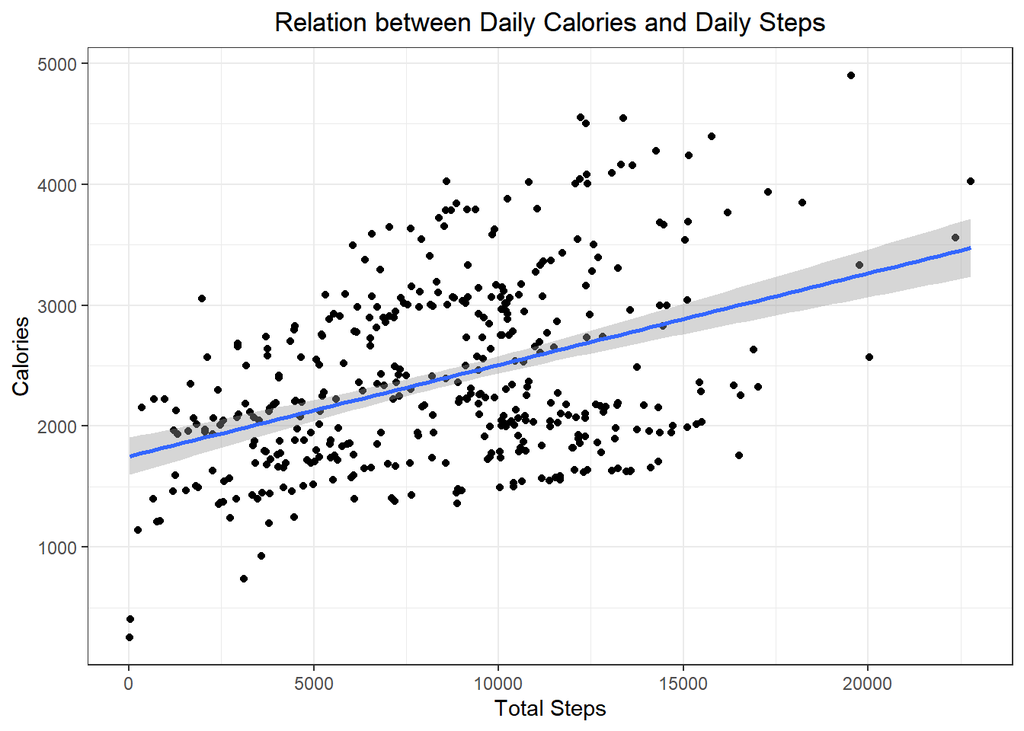

```r
ggplot(data = dailyActivity, mapping = aes(x = TotalSteps, y = Calories)) + geom_jitter() + geom_smooth(method = lm) + theme_bw() + labs(title = "Relation between Daily Calories and Daily Steps", x = "Total Steps") +theme(plot.title = element_text(hjust = 0.5))
```

By plotting the relation between Daily Calories and Daily Steps when each point is an entry from a user, it is clear that there is a positive correlation between both variables, meaning the more active you are, more calories are spent.

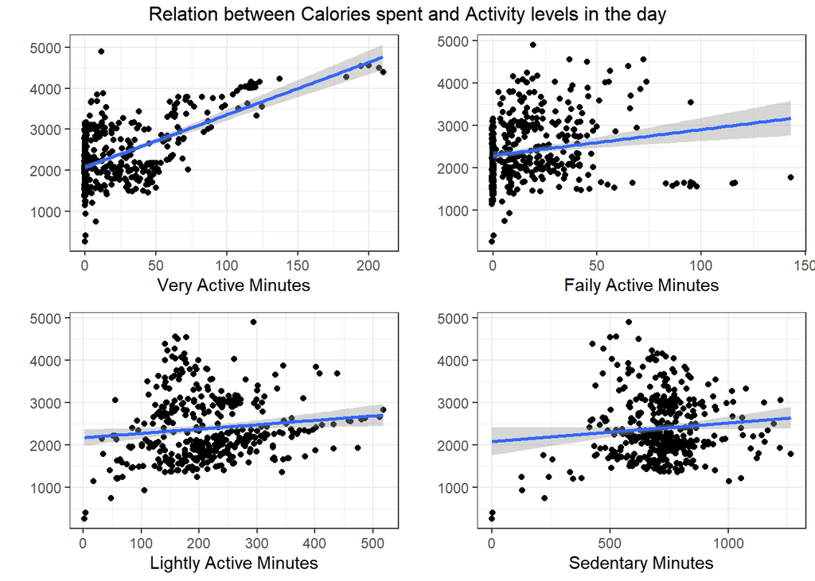

```r
plot1 <- ggplot(data = dailyActivity, mapping = aes(x = VeryActiveMinutes, y = Calories)) + geom_jitter() + geom_smooth(method = lm) + theme_bw() + labs(x = "Very Active Minutes", y = "")

plot2 <- ggplot(data = dailyActivity, mapping = aes(x = FairlyActiveMinutes, y = Calories)) + geom_jitter() + geom_smooth(method = lm) + theme_bw() + labs(x = "Faily Active Minutes", y = "")

plot3 <- ggplot(data = dailyActivity, mapping = aes(x = LightlyActiveMinutes, y = Calories)) + geom_jitter() + geom_smooth(method = lm) + theme_bw() + labs(x = "Lightly Active Minutes", y =  "")

plot4 <- ggplot(data = dailyActivity, mapping = aes(x = SedentaryMinutes, y = Calories)) + geom_jitter() + geom_smooth(method = lm) + theme_bw() + labs(x = "Sedentary Minutes", y = "")

grid.arrange(plot1, plot2, plot3, plot4, ncol=2, top = "Relation between Calories spent and Activity levels in the day")
```

When it comes to the relation between calories spent during the day and the level of activity, having very active minutes in a day may contribute directly to spending more calories, even in smaller amounts. Whereas light activity or sedentary minutes have almost no correlation with calorie expenditure.

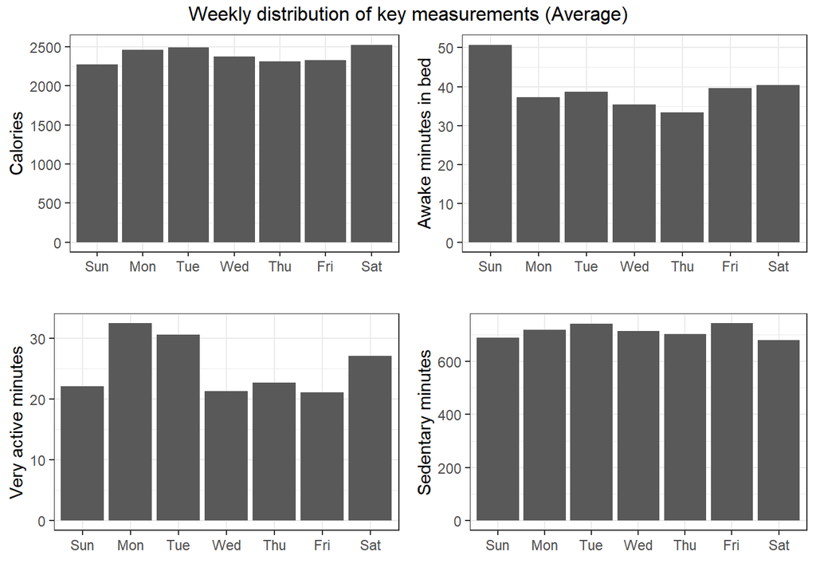

```r
plot5 <- ggplot(dailyActivity, aes(x= factor(Weekday, levels = c("Sun", "Mon", "Tue", "Wed", "Thu", "Fri", "Sat")), y = Calories)) + stat_summary(geom = "col", fun = "mean") + theme_bw() + labs(x = "")

plot6 <- ggplot(dailyActivity, aes(x= factor(Weekday, levels = c("Sun", "Mon", "Tue", "Wed", "Thu", "Fri", "Sat")), y = TotalAwakeTimeInBed)) + stat_summary(geom = "col", fun = "mean") + theme_bw() + labs(x = "", y = "Awake minutes in bed")
plot7 <- ggplot(dailyActivity, aes(x= factor(Weekday, levels = c("Sun", "Mon", "Tue", "Wed", "Thu", "Fri", "Sat")), y = VeryActiveMinutes)) + stat_summary(geom = "col", fun = "mean") + theme_bw() + labs(x = "", y = "Very active minutes")
plot8 <- ggplot(dailyActivity, aes(x= factor(Weekday, levels = c("Sun", "Mon", "Tue", "Wed", "Thu", "Fri", "Sat")), y = SedentaryMinutes)) + stat_summary(geom = "col", fun = "mean") + theme_bw() + labs(x = "", y = "Sedentary minutes")

grid.arrange(plot5, plot6, plot7, plot8, ncol=2, top = "Weekly distribution of key measurements (Average)")
```

## Conclusion

Based on those insights, I would suggest that the marketing team should focus on sharing a message that the Bellabeat products promote the creation of long-lasting healthy habits that help its customers to have a more active and balanced life.